# Enfoque estadístico del aprendizaje

# **Trabajo práctico nº1: regresión lineal**

### **Datos a utilizar:**

Los datos con los que se trabajará en este TP provienen de la 3° Encuesta Mundial de Salud Escolar (EMSE) provistos por el Ministerio de Salud de la República Argentina. Esta encuesta trata sobre temas de salud y hábitos de las personas en la escuela secundaria que pueden impactar en su salud.

Los datasets que se comparten corresponden a un recorte (muestra) del dataset original, luego del tratamiento de valores atípicos e ingeniería de atributos.

Las **variables** incluidas son:

| Variable | Descripción |
| --- | --- |
| **record** | ID de la observación |
| **edad** | Edad en años |
| **genero** | género de la persona |
| **nivel_educativo** | nivel educativo en que se encuentra la persona |
| **altura** | altura en centímetros |
| **peso** | peso en kilogramos |
| **frecuencia_hambre_mensual** | variable categórica que indica la frecuencia con la que la persona considera que pasó hambre en el último mes porque no había suficiente comida en su hogar |
| **dias_consumo_comida_rapida** | cuántos días comió en un restaurante de comida rápida en la última semana |
| **edad_consumo_alcohol** | edad en qué la persona comenzó a consumir alcohol |
| **consumo_diario_alcohol** | cantidad de tragos que la persona habitualmente toma por día |
| **dias_actividad_fisica_semanal** | cantidad de días que la persona realizó una actividad física por un total de al menos 60 minutos en la última semana |
| **consumo_semanal_frutas** | cantidad de veces que la persona consumió frutas en la última semana |
| **consumo_semanal_verdura** | cantidad de veces que la persona consumió gaseosas (al menos un vaso) en la última semana |
| **consumo_semanal_gaseosas** | cantidad de veces que la persona consumió snacks/comida salada en la última semana |
| **consumo_semanal_snacks** | cantidad de veces que la persona consumió snacks/comida salada en la última semana |
| **consumo_semanal_comida_grasa** | cantidad de veces que la persona consumió comidas altas en grasas en la última semana |

### **Consignas:**

El objetivo general del trabajo es poder crear una serie de modelos lineales para explicar y predecir el peso de los estudiantes según la información que proporciona la EMSE.

Se cargan las librerías con las que se va a realizar el trabajo:

```r
library(tidyverse)
library(tidymodels)
library(ggplot2)
library(knitr)
library(GGally)
library(robust)

options(scipen=999)
```

Importo el dataset:

```r
encuesta_salud <- read.csv("encuesta_salud_train.csv")
```

#### **1) Análisis exploratorio**

Primero, observo algunos registros del dataset:

```r
encuesta_salud %>% sample_n(5)
```

| record | edad | genero | nivel_educativo | altura | peso | frecuencia_hambre_mensual | dias_consumo_comida_rapida | edad_consumo_alcohol | consumo_diario_alcohol | dias_actividad_fisica_semanal | consumo_semanal_frutas | consumo_semanal_verdura | consumo_semanal_gaseosas | consumo_semanal_snacks | consumo_semanal_comida_grasa |
| --- | --- | --- | --- | --- | --- | --- | --- | --- | --- | --- | --- | --- | --- | --- | --- |
| 34469 | 16 | Masculino | 1er año/10mo grado nivel Polimodal o 3er año nivel Secundario | 179 | 65 | Nunca | 1 | Nunca tomé alcohol más que unos pocos sorbos | 0 | 7 | 1 a 3 veces durante los últimos 7 días | 4 a 6 veces durante los últimos 7 días | 1 a 3 veces durante los últimos 7 días | No comí comida salada o snacks en los últimos 7 días | 1 a 3 veces durante los últimos 7 días |
| 15479 | 14 | Femenino | 8vo grado nivel Primario/Polimodal o 1er año nivel Secundario | 153 | 52 | Rara vez | 0 | Nunca tomé alcohol más que unos pocos sorbos | 0 | 2 | No comí frutas durante los últimos 7 días | 2 veces al día | 4 o más veces al día | 1 a 3 veces durante los últimos 7 días | 1 vez al día |
| 19327 | 17 | Masculino | 3er año/12vo grado nivel Polimodal o 5to año nivel Secundario | 176 | 62 | Nunca | 0 | 14 o 15 años | 0 | 4 | 1 a 3 veces durante los últimos 7 días | 1 vez al día | 1 a 3 veces durante los últimos 7 días | 1 vez al día | 1 a 3 veces durante los últimos 7 días |
| 54067 | 14 | Masculino | 1er año/10mo grado nivel Polimodal o 3er año nivel Secundario | 170 | 61 | Nunca | 2 | 12 o 13 años | 5 | 7 | 1 vez al día | 1 a 3 veces durante los últimos 7 días | 1 a 3 veces durante los últimos 7 días | 4 a 6 veces durante los últimos 7 días | 1 a 3 veces durante los últimos 7 días |
| 23641 | 15 | Masculino | 9no grado nivel Primario/Polimodal o 2do año nivel Secundario | 178 | 48 | Rara vez | 0 | 12 o 13 años | 1 | 0 | No comí frutas durante los últimos 7 días | No comí verduras ni hortalizas durante los últimos 7 días | 1 a 3 veces durante los últimos 7 días | 1 a 3 veces durante los últimos 7 días | 4 a 6 veces durante los últimos 7 días |

Observo las dimensiones, los tipos de las variables y algunos ejemplos de cada una de ellas:

```r
glimpse(encuesta_salud)
```

```
## Rows: 7,024
## Columns: 16
## $ record                        <int> 502, 26488, 31473, 14154, 36578, 53730, …
## $ edad                          <int> 17, 15, 15, 16, 17, 15, 13, 17, 17, 16, …
## $ genero                        <chr> "Femenino", "Masculino", "Masculino", "M…
## $ nivel_educativo               <chr> "2do año/11vo grado nivel Polimodal o 4t…
## $ altura                        <int> 165, 178, 172, 170, 170, 178, 156, 163, …
## $ peso                          <int> 62, 62, 62, 65, 75, 88, 46, 60, 57, 51, …
## $ frecuencia_hambre_mensual     <chr> "Rara vez", "Rara vez", "Nunca", "Nunca"…
## $ dias_consumo_comida_rapida    <int> 0, 0, 3, 1, 1, 2, 0, 0, 0, 3, 4, 2, 1, 1…
## $ edad_consumo_alcohol          <chr> "14 o 15 años", "7 años o menos", "Nunca…
## $ consumo_diario_alcohol        <dbl> 5.0, 4.0, 0.0, 0.0, 0.0, 5.0, 1.0, 0.5, …
## $ dias_actividad_fisica_semanal <int> 7, 7, 7, 7, 0, 7, 0, 2, 7, 3, 2, 2, 7, 1…
## $ consumo_semanal_frutas        <chr> "No comí frutas durante los últimos 7 dí…
## $ consumo_semanal_verdura       <chr> "4 a 6 veces durante los últimos 7 días"…
## $ consumo_semanal_gaseosas      <chr> "1 a 3 veces durante los últimos 7 días"…
## $ consumo_semanal_snacks        <chr> "1 a 3 veces durante los últimos 7 días"…
## $ consumo_semanal_comida_grasa  <chr> "No comí comida alta en grasa en los últ…
```

Aquí se puede ver que el dataset cuenta con 7024 observaciones para las cuales se tienen 16 variables (7 de ellas numéricas y 9 categóricas). La variable peso, que es una de las variables numéricas, es la variable a explicar con el resto.

A continuación, observamos si las variables numéricas - y fundamentalmente el peso - están correlacionadas o no. Para ello, se procede a aperturar por el género de cada una de las personas:

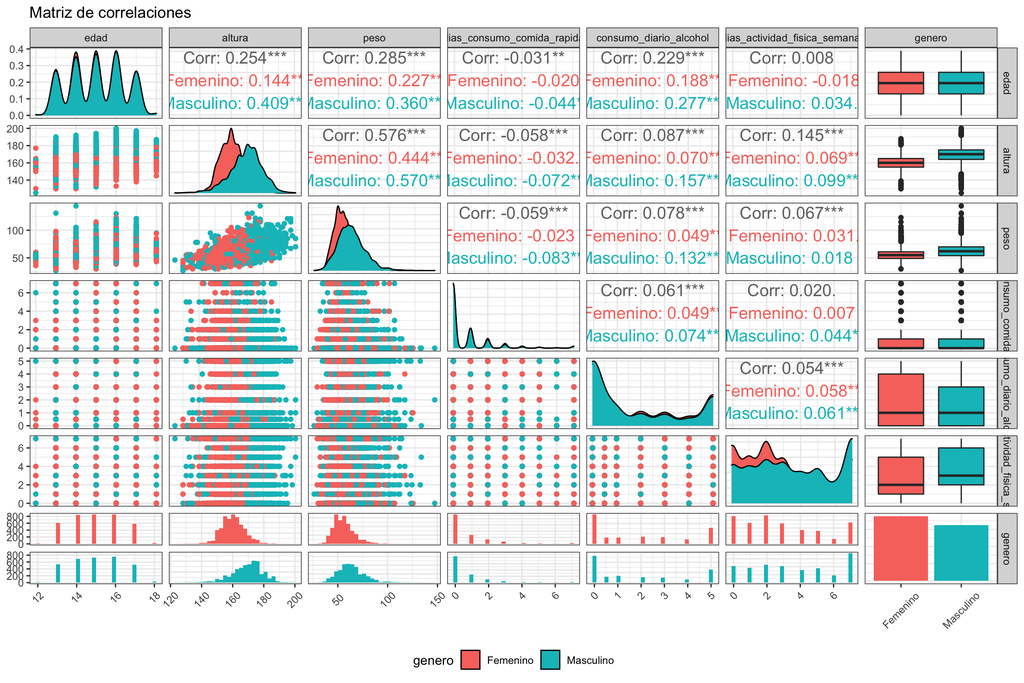

```r
encuesta_salud %>%
  select(where(is.numeric), genero, -record) %>%
  ggpairs(mapping = aes(color = genero), title = "Matriz de correlaciones",
          upper = list(continuous = wrap("cor", size = 5, hjust=0.5)), legend = 25) +
  theme_bw() +
  theme(axis.text.x = element_text(angle=45, vjust=0.5), legend.position = "bottom")
```

En los gráficos, se observa que existe correlación lineal de moderada a fuerte entre el peso y la altura (0,57 para las personas de género masculino, 0,44 para las de género femenino. También hay una correlación moderada entre la edad y el peso (0.285)

```r
encuesta_salud %>%
  group_by(genero) %>%
  summarise(cor = cor(altura, peso))
```

| genero | cor |
| --- | --- |
| Femenino | 0.4439202 |
| Masculino | 0.5704367 |

Luego, observamos qué categorías existen para la “frecuencia de hambre mensual”:

```r
encuesta_salud %>%
  select(frecuencia_hambre_mensual) %>%
  table() %>%
  prop.table() %>%
  sort(decreasing = TRUE)
```

```
## .
##         Nunca      Rara vez Algunas veces  Casi siempre  Dato perdido
##   0.689635535   0.206007973   0.083855353   0.011104784   0.005552392
##       Siempre
##   0.003843964
```

Para cada una de ellas, observamos cómo se distribuye el consumo semanal de verdura:

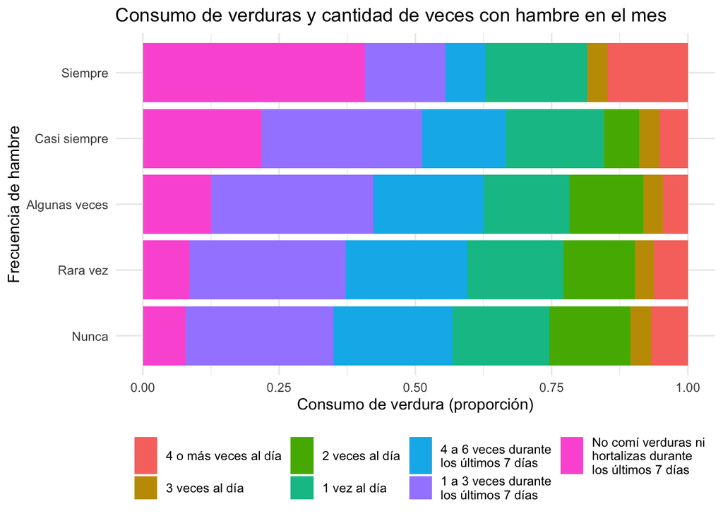

```r
tabla = encuesta_salud %>%
  filter(frecuencia_hambre_mensual != 'Dato perdido') %>%
  filter(consumo_semanal_verdura != 'Dato perdido') %>%
  select(consumo_semanal_verdura, frecuencia_hambre_mensual) %>%
  table()
tabla = as.data.frame(tabla)
colnames(tabla) <- c("consumo_semanal_verdura", "frecuencia_hambre_mensual", "q")

order = c("Nunca", "Rara vez", "Algunas veces", "Casi siempre", "Siempre")
type = c("4 o más veces al día", "3 veces al día", "2 veces al día", "1 vez al día", "4 a 6 veces durante los últimos 7 días", "1 a 3 veces durante los últimos 7 días", "No comí verduras ni hortalizas durante los últimos 7 días")


ggplot(tabla) +
 aes(x = frecuencia_hambre_mensual,
     fill = factor(str_wrap(consumo_semanal_verdura, 20), levels = str_wrap(type, 20)),
     weight = q) +
 geom_bar(position = "fill") +
 scale_fill_hue(direction = 1) +
 coord_flip() +
 theme_minimal() +
 theme(legend.position = "bottom") +
 theme(legend.title=element_blank()) +
 labs(x = "Frecuencia de hambre",  y = "Consumo de verdura (proporción)", title = "Consumo de verduras y cantidad de veces con hambre en el mes") +
 scale_x_discrete(limits = order)
```

En estos gráficos, se puede observar que aquellos que suelen pasar hambre (siempre o casi siempre) registran un menor consumo de verduras y hortalizas. En los primeros también hay un alto porcentaje de peresonas que comen verduras y/o hortalizas 4 o más veces por día lo que de alguna manera también habla de lo poco balanceadas que son sus dietas.

Observamos el mismo gráfico, pero para la frecuencia de hambre y el consumo de comidas grasas:

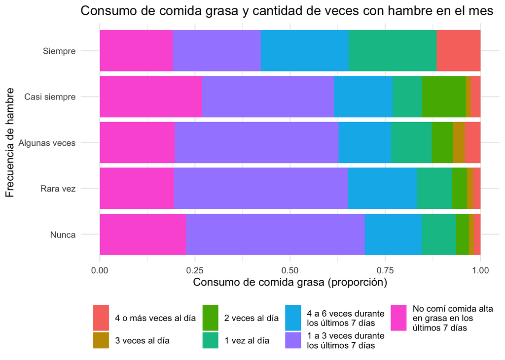

```r
tabla = encuesta_salud %>%
  filter(frecuencia_hambre_mensual != 'Dato perdido') %>%
  filter(consumo_semanal_comida_grasa != 'Dato perdido') %>%
  select(consumo_semanal_comida_grasa, frecuencia_hambre_mensual) %>%
  table()
tabla = as.data.frame(tabla)
colnames(tabla) <- c("consumo_semanal_comida_grasa", "frecuencia_hambre_mensual", "q")

order = c("Nunca", "Rara vez", "Algunas veces", "Casi siempre", "Siempre")
type = c("4 o más veces al día", "3 veces al día", "2 veces al día", "1 vez al día", "4 a 6 veces durante los últimos 7 días", "1 a 3 veces durante los últimos 7 días", "No comí comida alta en grasa en los últimos 7 días")


ggplot(tabla) +
 aes(x = frecuencia_hambre_mensual,
     fill = factor(str_wrap(consumo_semanal_comida_grasa, 20), levels = str_wrap(type, 20)),
     weight = q) +
 geom_bar(position = "fill") +
 scale_fill_hue(direction = 1) +
 coord_flip() +
 theme_minimal() +
 theme(legend.position = "bottom") +
 theme(legend.title=element_blank()) +
 labs(x = "Frecuencia de hambre",  y = "Consumo de comida grasa (proporción)", title = "Consumo de comida grasa y cantidad de veces con hambre en el mes") +
 scale_x_discrete(limits = order)
```

En cuanto a comida grasa, se ve que aquellos que suelen pasar hambre tienen un alto consumo: muchos de ellos consumen todos los días.

Se ve en los dos gráficos que los que más frecuentemente pasan hambre son los que suelen tener peores hábitos alimenticios y/o dietas menos balanceadas.

#### **2) Modelo inicial**

La primera alternativa para modelar el peso, es la siguiente:

$$E(peso) = \beta_{0} + \beta_{1} altura+ \beta_{2} edad+ \beta_{3} genero
+ \beta_{4} diasActividadF isicaSemanal + \beta_{5} consumoDiarioAlcohol$$

Ajusto el modelo lineal:

```r
modelo_simple = lm(peso ~ altura + edad + genero + dias_actividad_fisica_semanal + consumo_diario_alcohol, data=encuesta_salud)

tidy_modelo_simple <- tidy(modelo_simple, conf.int = TRUE)
tidy_modelo_simple
```

| term | estimate | std.error | statistic | p.value | conf.low | conf.high |
| --- | --- | --- | --- | --- | --- | --- |
| (Intercept) | -68.922688070 | 2.33805445 | -29.4786497 | 0.000000000000000000000000000000000000000000000000000000000000000000000000000000000000000000000000000000000000000000000000000000000000000000000000000000000000000000000000000000000003614866 | -73.5059810 | -64.33939510 |
| altura | 0.650606544 | 0.01437975 | 45.2446353 | 0.000000000000000000000000000000000000000000000000000000000000000000000000000000000000000000000000000000000000000000000000000000000000000000000000000000000000000000000000000000000000000000 | 0.6224179 | 0.67879520 |
| edad | 1.406727060 | 0.09385081 | 14.9889709 | 0.000000000000000000000000000000000000000000000000051215989492540952802144340705092002395050673984056257631881931432103593409134421509989307930075511480093288227665638447845563620275388672 | 1.2227511 | 1.59070300 |
| generoMasculino | 1.262643558 | 0.27282821 | 4.6279802 | 0.000003758830987837418888052954182854570319705089787021279335021972656250000000000000000000000000000000000000000000000000000000000000000000000000000000000000000000000000000000000000000000 | 0.7278179 | 1.79746926 |
| dias_actividad_fisica_semanal | -0.087391031 | 0.04992917 | -1.7503000 | 0.080110250029061830234766716785088647156953811645507812500000000000000000000000000000000000000000000000000000000000000000000000000000000000000000000000000000000000000000000000000000000000 | -0.1852673 | 0.01048523 |
| consumo_diario_alcohol | 0.007271379 | 0.06138558 | 0.1184542 | 0.905711181897993267142510376288555562496185302734375000000000000000000000000000000000000000000000000000000000000000000000000000000000000000000000000000000000000000000000000000000000000000 | -0.1130629 | 0.12760566 |

El valor de $\beta_{0}$ nos indica que el peso esperado para una mujer de 0 cm de altura, 0 años, que no realiza actividad física y que no consume alcohol es de -68.92 kg.

El coeficiente que multiplica a la altura $\beta_{1}$ es 0.65. Significa que ante cada cm adicional de altura el peso promedio aumenta en 0,65 kg manteniendo todas las otras variables constantes

El coeficiente que multiplica a generoMasculino es 1.26, de lo que se deduce que el peso esperado para una persona recién nacida de género masculino de 0 cm de altura, que no realiza actividad física ni consume alcohol es de -67,65 (-68.92 + 1.2626).

El valor de $\beta_{4}$ nos muestra que ante cada día de actividad física adicional el peso promedio disminuye en 0,08kg (manteniendo todas las otras variables constantes).

El valor de $\beta_{5}$ nos indica que ante cada trago diario adicional de alcohol el peso esperado de una persona aumenta en 0,007kg (manteniendo todas las otras variables constantes).

Sin embargo, no todas las variables son significativas. Tras realizar el test de significatividad individual para los días de actividad física semanal y para el consumo diario de alcohol se observan p-valores mayores a 0.05 por lo que no se rechaza la hipótesis nula ($\beta_{k}=0$). También se puede ver que los intervalos de confianza para ambos coeficientes contienen el 0, lo que nos da la pauta de que no son variables útiles para explicar el peso de una persona.

Por otro lado, el resto de las variables (altura, edad y género) sí resultan estadísticamente significativas para explicar el peso de una persona.

```r
glance(modelo_simple)
```

| r.squared | adj.r.squared | sigma | statistic | p.value | df | logLik | AIC | BIC | deviance | df.residual | nobs |
| --- | --- | --- | --- | --- | --- | --- | --- | --- | --- | --- | --- |
| 0.3543754 | 0.3539154 | 9.914373 | 770.4188 | 0 | 5 | -26076.58 | 52167.16 | 52215.15 | 689832.9 | 7018 | 7024 |

El $R^{2}$ del modelo, el porcentaje de variabilidad del fenómeno que el modelo logra explicar, es de 0,35. Considerando el p-valor, se rechaza la hipótesis nula del test de significatividad global y podemos concluir que al menos una de las variables regresoras sirve para explicar el peso de una persona.

#### **3) Modelo categóricas**

Luego, se probará con un modelo que incopora el consumo semanal de snacks y una interacción entre el género y la edad, en lugar de actividad física y consumo de alcohol:

$$E(peso) = \beta_{0} + \beta_{1} altura+ \beta_{2} edad+ \beta_{3} genero
+ \beta_{4} consumoSemanalSnacks + \beta_{5} genero.edad$$

Se harán algunas modificaciones para que el nivel basal del consumo semanal de snacks sea “no comí comida salada o snacks en los últimos 7 días:

```r
encuesta_salud$consumo_semanal_snacks <- relevel(as.factor(encuesta_salud$consumo_semanal_snacks), ref = "No comí comida salada o snacks en los últimos 7 días")

modelo_categoricas = lm(peso ~ altura + edad + genero + consumo_semanal_snacks + genero * edad, data=encuesta_salud)

tidy_modelo_categoricas <- tidy(modelo_categoricas, conf.int = TRUE)
tidy_modelo_categoricas
```

| term | estimate | std.error | statistic | p.value | conf.low | conf.high |
| --- | --- | --- | --- | --- | --- | --- |
| (Intercept) | -64.1994003 | 2.82848788 | -22.697428 | 0.00000000000000000000000000000000000000000000000000000000000000000000000000000000000000000000000000000000000004080837 | -69.74409176 | -58.6547088 |
| altura | 0.6429223 | 0.01452916 | 44.250469 | 0.00000000000000000000000000000000000000000000000000000000000000000000000000000000000000000000000000000000000000000000 | 0.61444077 | 0.6714039 |
| edad | 1.2230934 | 0.12102373 | 10.106228 | 0.00000000000000000000000754706503198596258080762106490406719106828318526548598390249901046028524476128040987532585859 | 0.98585034 | 1.4603365 |
| generoMasculino | -4.6115043 | 2.67876742 | -1.721502 | 0.08520382079196391067466009872077847830951213836669921875000000000000000000000000000000000000000000000000000000000000 | -9.86269837 | 0.6396898 |
| consumo_semanal_snacks1 a 3 veces durante los últimos 7 días | -1.3516324 | 0.27644506 | -4.889334 | 0.00000103428476720125661831358593323315631096193101257085800170898437500000000000000000000000000000000000000000000000 | -1.89354827 | -0.8097164 |
| consumo_semanal_snacks1 vez al día | -0.6078756 | 0.45601026 | -1.333031 | 0.18256509466496323446094152131990995258092880249023437500000000000000000000000000000000000000000000000000000000000000 | -1.50179360 | 0.2860424 |
| consumo_semanal_snacks2 veces al día | -1.0946603 | 0.68456905 | -1.599050 | 0.10985448360501159914548452434246428310871124267578125000000000000000000000000000000000000000000000000000000000000000 | -2.43662266 | 0.2473020 |
| consumo_semanal_snacks3 veces al día | -1.2759618 | 1.01150207 | -1.261452 | 0.20718783152043504514061567078897496685385704040527343750000000000000000000000000000000000000000000000000000000000000 | -3.25881168 | 0.7068881 |
| consumo_semanal_snacks4 a 6 veces durante los últimos 7 días | -2.2700362 | 0.44992485 | -5.045367 | 0.00000046403175018651888048177873297150952680567570496350526809692382812500000000000000000000000000000000000000000000 | -3.15202493 | -1.3880474 |
| consumo_semanal_snacks4 o más veces al día | -2.5669735 | 0.88112366 | -2.913295 | 0.00358765781176552086065290048111364740179851651191711425781250000000000000000000000000000000000000000000000000000000 | -4.29424225 | -0.8397047 |

[output cut: 2 more lines]

En este caso $\beta_{0}$ nos indica que el peso promedio de una mujer de 0 años, 0 cm, que no consume comida salada ni snacks es de -64.2 kg.

Por otro lado, el coeficiente edad.generoMasculino en este caso refleja que, para los hombres, un año adicional de edad aumenta el peso promedio en 1,22 + 0,39 kg manteniendo constantes el resto de las variables. La variable tiene un efecto significativo para explicar el peso.

Vamos a ver qué porcentaje de la variabilidad explica el modelo:

```r
glance(modelo_categoricas)
```

| r.squared | adj.r.squared | sigma | statistic | p.value | df | logLik | AIC | BIC | deviance | df.residual | nobs |
| --- | --- | --- | --- | --- | --- | --- | --- | --- | --- | --- | --- |
| 0.3585223 | 0.357516 | 9.886709 | 356.2737 | 0 | 11 | -26053.95 | 52133.89 | 52223.04 | 685402.1 | 7012 | 7024 |

El $R^{2}$ del modelo es de 0,3585.

Por último, considerando que algunas categorías consumoSemanalSnacks no resultan significativas, se va a realizar un test F para evaluar la significatividad conjunta de la variable para explicar al peso.

```r
tidy(anova(modelo_categoricas))
```

| term | df | sumsq | meansq | statistic | p.value |
| --- | --- | --- | --- | --- | --- |
| altura | 1 | 354474.0641 | 354474.06410 | 3626.443857 | 0.00000000000000000000000000000000000000000000000000000000 |
| edad | 1 | 21885.9340 | 21885.93402 | 223.903859 | 0.00000000000000000000000000000000000000000000000007444135 |
| genero | 1 | 1979.6086 | 1979.60864 | 20.252369 | 0.00000689648378643574615389074886073750292325712507590652 |
| consumo_semanal_snacks | 7 | 4264.6404 | 609.23434 | 6.232767 | 0.00000026588351710730774070130105757314709080674219876528 |
| edad:genero | 1 | 467.3655 | 467.36548 | 4.781378 | 0.02880201632312943613167810497088794363662600517272949219 |
| Residuals | 7012 | 685402.0731 | 97.74702 | NA | NA |

Considerando el p-valor, se concluye que la variable consumo_semanal_snacks es significativa para explicar el peso de una persona.

A continuación, se va a proponer un nueva definición de las categorías de consumoSemanalSnacks: se van a juntar “consume snacks 1 vez al día”, “consume snacks 2 veces al día”, “consume snacks 3 veces al día” y “consume snacks 4 o más veces al día” en una única categoría “consume snacks todos los días”, y se van a volver a estimar los coeficientes.

```r
encuesta_salud$consumo_semanal_snacks_new <- ifelse(encuesta_salud$consumo_semanal_snacks %in% c("1 vez al día", "2 veces al día", "3 veces al día", "4 o más veces al día"),
                                                    "Consume snacks todos los días",
                                                    as.character(encuesta_salud$consumo_semanal_snacks))
```

```r
encuesta_salud$consumo_semanal_snacks_new <- relevel(as.factor(encuesta_salud$consumo_semanal_snacks_new), ref = "No comí comida salada o snacks en los últimos 7 días")

modelo_categoricas_grouped = lm(peso ~ altura + edad + genero + consumo_semanal_snacks_new + genero * edad, data=encuesta_salud)

tidy_modelo_categoricas_grouped <- tidy(modelo_categoricas_grouped, conf.int = TRUE)
tidy_modelo_categoricas_grouped
```

| term | estimate | std.error | statistic | p.value | conf.low | conf.high |
| --- | --- | --- | --- | --- | --- | --- |
| (Intercept) | -64.2863859 | 2.82819660 | -22.730522 | 0.00000000000000000000000000000000000000000000000000000000000000000000000000000000000000000000000000000000000002015871 | -69.83050596 | -58.7422659 |
| altura | 0.6433834 | 0.01452789 | 44.286088 | 0.00000000000000000000000000000000000000000000000000000000000000000000000000000000000000000000000000000000000000000000 | 0.61490438 | 0.6718625 |
| edad | 1.2237855 | 0.12102490 | 10.111849 | 0.00000000000000000000000713107144731415502871800050091821684850424496930156975811531338237114763245472204289399087429 | 0.98654013 | 1.4610309 |
| generoMasculino | -4.4827423 | 2.67831330 | -1.673718 | 0.09423053398499363353391089503929833881556987762451171875000000000000000000000000000000000000000000000000000000000000 | -9.73304581 | 0.7675612 |
| consumo_semanal_snacks_new1 a 3 veces durante los últimos 7 días | -1.3514681 | 0.27647273 | -4.888251 | 0.00000103996182788916300248076469980862412967326235957443714141845703125000000000000000000000000000000000000000000000 | -1.89343826 | -0.8094980 |
| consumo_semanal_snacks_new4 a 6 veces durante los últimos 7 días | -2.2710079 | 0.44996961 | -5.047025 | 0.00000046003482047624992444187237011776758777159557212144136428833007812500000000000000000000000000000000000000000000 | -3.15308429 | -1.3889315 |
| consumo_semanal_snacks_newConsume snacks todos los días | -1.0209369 | 0.37058899 | -2.754903 | 0.00588608655560390794242442424888395180460065603256225585937500000000000000000000000000000000000000000000000000000000 | -1.74740329 | -0.2944705 |
| consumo_semanal_snacks_newDato perdido | -4.4409813 | 1.95144313 | -2.275742 | 0.02289146755589762174953882833960960851982235908508300781250000000000000000000000000000000000000000000000000000000000 | -8.26639956 | -0.6155630 |
| edad:generoMasculino | 0.3830080 | 0.17899396 | 2.139781 | 0.03240683013460832900820562940680247265845537185668945312500000000000000000000000000000000000000000000000000000000000 | 0.03212571 | 0.7338902 |

A continuación, se va a consultar la variabilidad explicada por el modelo:

```r
glance(modelo_categoricas_grouped)
```

| r.squared | adj.r.squared | sigma | statistic | p.value | df | logLik | AIC | BIC | deviance | df.residual | nobs |
| --- | --- | --- | --- | --- | --- | --- | --- | --- | --- | --- | --- |
| 0.3581192 | 0.3573872 | 9.8877 | 489.2275 | 0 | 8 | -26056.15 | 52132.31 | 52200.88 | 685832.8 | 7015 | 7024 |

Sin embargo, con la nueva agrupación no hay una mejora en el $R^2$ ni en el $R^2 ajustado$ del modelo.

#### **4) Modelos propios y evaluación**

A continuación, se sugieren dos posibles modelos adicionales para intentar explicar el peso de una persona:

A:
$$E(peso) = \beta_{0} + \beta_{1} altura+ \beta_{2} edad+ \beta_{3} genero
+ \beta_{4} consumoSemanalSnacksNew + \\ \beta_{5} consumoSemanalGaseosa
+ \beta_{6} diasConsumoComidaRapida + \beta_{7} genero.edad + \beta_{8}
genero.altura$$

El primer modelo propuesto incorpora una interacción entre género y altura, ya que es posible que un cm adicional de altura contribuya al peso distinto en hombres y mujeres.Y el consumo semanal de gaseosa y de comida rápida, dos factores que pueden contribuir enormemente en el aumento de peso de un niño.

B:

$$E(peso) = \beta_{0} + \beta_{1} altura+ \beta_{2} edad+ \beta_{3} genero
+ \beta_{4} edad^2 + \beta_{6} genero.edad + \beta_{7} genero.altura +
\beta_{7} haceActividadFisica + \\ \beta_{7} haceActividadFisica . edad
+\beta_{7} buenoshabitos$$

El segundo modelo propuesto, además de la interacción entre género y altura, incorpora la edad al cuadrado para que explique el efecto de una eventual desaceleración del aumento del peso a medida que aumenta la edad, la variable hace_actividad_fisica que va a ser un booleano que va a tomar valor 1 en caso de que haga actividad física 3 o más veces por semana, la variable buenos_habitos que va a ser un valor entero que va a tratar de reflejar cuántos hábitos buenos acumula una persona: va a ser la sumatoria de lo siguiente:

y por último, una interacción entre la edad y la variable hace_actividad_fisica, posiblemente un año adicional de vida no aporte lo mismo al peso promedio si hace o no actividad física.

Observamos el ajuste del **modelo A**:

```r
modelo_a = lm(peso ~ altura + edad + genero + consumo_semanal_snacks_new + consumo_semanal_gaseosas + dias_consumo_comida_rapida + genero * edad + genero * altura, data=encuesta_salud)

tidy_modelo_a <- tidy(modelo_a, conf.int = TRUE)
tidy_modelo_a
```

| term | estimate | std.error | statistic | p.value | conf.low | conf.high |
| --- | --- | --- | --- | --- | --- | --- |
| (Intercept) | -56.34749464 | 3.76152151 | -14.97997406 | 0.00000000000000000000000000000000000000000000000005857066008225350707040023666036341395869745165022816304506830547338985863904524866267364918020225130652352 | -63.72121521 | -48.97377406 |
| altura | 0.59036639 | 0.02213898 | 26.66637810 | 0.00000000000000000000000000000000000000000000000000000000000000000000000000000000000000000000000000000000000000000000000000000000000000000000000000002674565 | 0.54696729 | 0.63376549 |
| edad | 1.26244915 | 0.12154949 | 10.38629747 | 0.00000000000000000000000043507258657416537087129610129087832315156472775735105202603426015209656108062574730865890160202980041503906250000000000000000000000 | 1.02417537 | 1.50072294 |
| generoMasculino | -16.87735253 | 4.84702997 | -3.48199880 | 0.00050072254325651875759423115042068275215569883584976196289062500000000000000000000000000000000000000000000000000000000000000000000000000000000000000000000 | -26.37899821 | -7.37570685 |
| consumo_semanal_snacks_new1 a 3 veces durante los últimos 7 días | -1.21627250 | 0.28148582 | -4.32090157 | 0.00001575400317833506225097955910641189802845474332571029663085937500000000000000000000000000000000000000000000000000000000000000000000000000000000000000000 | -1.76806989 | -0.66447511 |
| consumo_semanal_snacks_new4 a 6 veces durante los últimos 7 días | -1.96785166 | 0.46128496 | -4.26602177 | 0.00002016073605295125512602318063049011698240065015852451324462890625000000000000000000000000000000000000000000000000000000000000000000000000000000000000000 | -2.87210978 | -1.06359354 |
| consumo_semanal_snacks_newConsume snacks todos los días | -0.52555154 | 0.39440243 | -1.33252612 | 0.18273070120726261911237031654309248551726341247558593750000000000000000000000000000000000000000000000000000000000000000000000000000000000000000000000000000 | -1.29869967 | 0.24759659 |
| consumo_semanal_snacks_newDato perdido | -3.95265954 | 1.95712696 | -2.01962347 | 0.04346045707201284108434080621918838005512952804565429687500000000000000000000000000000000000000000000000000000000000000000000000000000000000000000000000000 | -7.78922071 | -0.11609838 |
| consumo_semanal_gaseosas1 vez al día | -0.07449377 | 0.43329624 | -0.17192342 | 0.86350269725648276519791579630691558122634887695312500000000000000000000000000000000000000000000000000000000000000000000000000000000000000000000000000000000 | -0.92388554 | 0.77489799 |
| consumo_semanal_gaseosas2 veces al día | -1.39683478 | 0.49075106 | -2.84632044 | 0.00443561615668277252344520178439779556356370449066162109375000000000000000000000000000000000000000000000000000000000000000000000000000000000000000000000000 | -2.35885538 | -0.43481417 |

[output cut: 8 more lines]

también observamos lo que resulta de realizar el test de significatividad conjunta de las variables del modelo:

```r
tidy(anova(modelo_a))
```

| term | df | sumsq | meansq | statistic | p.value |
| --- | --- | --- | --- | --- | --- |
| altura | 1 | 354474.0641 | 354474.06410 | 3638.483733 | 0.00000000000000000000000000000000000000000000000000000000 |
| edad | 1 | 21885.9340 | 21885.93402 | 224.647225 | 0.00000000000000000000000000000000000000000000000005192226 |
| genero | 1 | 1979.6086 | 1979.60864 | 20.319607 | 0.00000665909830947631883256128751402691534622135804966092 |
| consumo_semanal_snacks_new | 4 | 3853.6718 | 963.41795 | 9.888962 | 0.00000005623269321817442810013132088037268729863171756733 |
| consumo_semanal_gaseosas | 7 | 2228.1971 | 318.31386 | 3.267319 | 0.00181591841877429792384557316609061672352254390716552734 |
| dias_consumo_comida_rapida | 1 | 127.3160 | 127.31601 | 1.306830 | 0.25300852372747811847020216191594954580068588256835937500 |
| edad:genero | 1 | 470.5819 | 470.58188 | 4.830267 | 0.02799689786746964448305163841723697260022163391113281250 |
| altura:genero | 1 | 904.8010 | 904.80101 | 9.287291 | 0.00231608938126132016602221064260902494424954056739807129 |
| Residuals | 7006 | 682549.5111 | 97.42357 | NA | NA |

Observando la significatividad conjunta de las variables, todas ellas resultan significativas, salvo los días de consumo de comida rápida. Si observamos la significatividad individual de cada una de las categorías, hay algunas de ellas que no resultan significativas, quizás sea una buena idea agrupar de otra forma.

A continuación, se crean las variables nuevas que se van a incluir en el segundo modelo:

```r
encuesta_salud = encuesta_salud %>%
  mutate(hace_actividad_fisica = if_else(dias_actividad_fisica_semanal >= 3, 1, 0),
         buenos_habitos = if_else(dias_consumo_comida_rapida > 0, -1, 0) +
                          if_else(consumo_diario_alcohol > 1, -1, 0) +
                          if_else(consumo_semanal_frutas %in% c("1 vez al día", "2 veces al día", "3 veces al día", "4 o más veces al día"), 1, 0) +
                          if_else(hace_actividad_fisica == 1, 1, 0) +
                          if_else(consumo_semanal_verdura %in% c("1 vez al día", "2 veces al día", "3 veces al día", "4 o más veces al día"), 1, 0) +
                          if_else(consumo_semanal_gaseosas %in% c("1 vez al día", "2 veces al día", "3 veces al día", "4 o más veces al día"), -1, 0) +
                          if_else(consumo_semanal_snacks %in% c("1 vez al día", "2 veces al día", "3 veces al día", "4 o más veces al día"), -1, 0) +
                          if_else(consumo_semanal_comida_grasa %in% c("1 vez al día", "2 veces al día", "3 veces al día", "4 o más veces al día"), -1, 0),
         edad_cuadrada = edad * edad
                          )
```

Ajuste del **modelo B** :

```r
modelo_b = lm(peso ~ altura + edad + genero + edad_cuadrada + genero * edad + genero * altura + hace_actividad_fisica + hace_actividad_fisica * edad + buenos_habitos, data=encuesta_salud)

tidy_modelo_b <- tidy(modelo_b, conf.int = TRUE)
tidy_modelo_b
```

| term | estimate | std.error | statistic | p.value | conf.low | conf.high |
| --- | --- | --- | --- | --- | --- | --- |
| (Intercept) | -76.59782228 | 15.67801558 | -4.8856835 | 0.000001053564362739979695337525118781218935737342690117657184600830078125000000000000000000000000000000000000000000000000000000000000000000000000000000000 | -107.331471671 | -45.86417289 |
| altura | 0.58944824 | 0.02224748 | 26.4950513 | 0.000000000000000000000000000000000000000000000000000000000000000000000000000000000000000000000000000000000000000000000000000000000000000000000000001654588 | 0.545836442 | 0.63306003 |
| edad | 3.91853614 | 2.05371961 | 1.9080190 | 0.056429544015879053164841394618633785285055637359619140625000000000000000000000000000000000000000000000000000000000000000000000000000000000000000000000000 | -0.107375060 | 7.94444734 |
| generoMasculino | -16.91309623 | 4.86297962 | -3.4779287 | 0.000508370533083084470173107494161968133994378149509429931640625000000000000000000000000000000000000000000000000000000000000000000000000000000000000000000 | -26.446006178 | -7.38018628 |
| edad_cuadrada | -0.08907250 | 0.06821989 | -1.3056677 | 0.191708401452151067090312608343083411455154418945312500000000000000000000000000000000000000000000000000000000000000000000000000000000000000000000000000000 | -0.222804101 | 0.04465909 |
| hace_actividad_fisica | -2.18578142 | 2.67788006 | -0.8162357 | 0.414393037100321492971488623879849910736083984375000000000000000000000000000000000000000000000000000000000000000000000000000000000000000000000000000000000 | -7.435235749 | 3.06367291 |
| buenos_habitos | 0.16783437 | 0.08821322 | 1.9025990 | 0.057133807587891542734137573233965667895972728729248046875000000000000000000000000000000000000000000000000000000000000000000000000000000000000000000000000 | -0.005090193 | 0.34075894 |
| edad:generoMasculino | 0.21723105 | 0.18744580 | 1.1589006 | 0.246536151889286597738148998359974939376115798950195312500000000000000000000000000000000000000000000000000000000000000000000000000000000000000000000000000 | -0.150219374 | 0.58468148 |
| altura:generoMasculino | 0.09124502 | 0.02938820 | 3.1048186 | 0.001911545132291886600964248010825485835084691643714904785156250000000000000000000000000000000000000000000000000000000000000000000000000000000000000000000 | 0.033635271 | 0.14885477 |
| edad:hace_actividad_fisica | 0.11500557 | 0.17758684 | 0.6476019 | 0.517263677178526948274850383313605561852455139160156250000000000000000000000000000000000000000000000000000000000000000000000000000000000000000000000000000 | -0.233118315 | 0.46312946 |

Se observa que la edad cuadrada, “hace_actividad_fisica” (y las interacciones armadas) y “buenos_habitos” no resultan significativas para explicar el peso de un adolescente.

A continuación, se van a comparar los distintos modelos desarrollados. En primer lugar, se carga el dataset de test en el que vamos a medir la performance de los modelos:

```r
encuesta_salud_test <- read.csv("encuesta_salud_test.csv")
```

Se crea la variable consumo semanal snacks con la nueva agrupación también para el dataset de test y lo mismo con el resto de las variables creadas:

```r
encuesta_salud_test$consumo_semanal_snacks_new <- ifelse(encuesta_salud_test$consumo_semanal_snacks %in% c("1 vez al día", "2 veces al día", "3 veces al día", "4 o más veces al día"),
                                                    "Consume snacks todos los días",
                                                    as.character(encuesta_salud_test$consumo_semanal_snacks))

encuesta_salud_test = encuesta_salud_test %>%
  mutate(hace_actividad_fisica = if_else(dias_actividad_fisica_semanal >= 3, 1, 0),
         buenos_habitos = if_else(dias_consumo_comida_rapida > 0, -1, 0) +
                          if_else(consumo_diario_alcohol > 1, -1, 0) +
                          if_else(consumo_semanal_frutas %in% c("1 vez al día", "2 veces al día", "3 veces al día", "4 o más veces al día"), 1, 0) +
                          if_else(hace_actividad_fisica == 1, 1, 0) +
                          if_else(consumo_semanal_verdura %in% c("1 vez al día", "2 veces al día", "3 veces al día", "4 o más veces al día"), 1, 0) +
                          if_else(consumo_semanal_gaseosas %in% c("1 vez al día", "2 veces al día", "3 veces al día", "4 o más veces al día"), -1, 0) +
                          if_else(consumo_semanal_snacks %in% c("1 vez al día", "2 veces al día", "3 veces al día", "4 o más veces al día"), -1, 0) +
                          if_else(consumo_semanal_comida_grasa %in% c("1 vez al día", "2 veces al día", "3 veces al día", "4 o más veces al día"), -1, 0),
         edad_cuadrada = edad * edad
                          )
```

Se arma una lista con todos los modelos construídos

```r
models <- list(modelo_simple = modelo_simple,
               modelo_categorias = modelo_categoricas_grouped,
               modelo_a = modelo_a,
               modelo_b = modelo_b)
```

En el dataset de train, se observa el $R^2$ de todos los modelos

```r
evaluacion_train = map_df(models, glance, .id = "model") %>%
  arrange(desc(adj.r.squared))

evaluacion_train
```

| model | r.squared | adj.r.squared | sigma | statistic | p.value | df | logLik | AIC | BIC | deviance | df.residual | nobs |
| --- | --- | --- | --- | --- | --- | --- | --- | --- | --- | --- | --- | --- |
| modelo_a | 0.3611920 | 0.3596420 | 9.870338 | 233.0178 | 0 | 17 | -26039.30 | 52116.60 | 52246.88 | 682549.5 | 7006 | 7024 |
| modelo_categorias | 0.3581192 | 0.3573872 | 9.887700 | 489.2275 | 0 | 8 | -26056.15 | 52132.31 | 52200.88 | 685832.8 | 7015 | 7024 |
| modelo_b | 0.3560445 | 0.3552182 | 9.904373 | 430.8952 | 0 | 9 | -26067.49 | 52156.97 | 52232.40 | 688049.5 | 7014 | 7024 |
| modelo_simple | 0.3543754 | 0.3539154 | 9.914373 | 770.4188 | 0 | 5 | -26076.58 | 52167.16 | 52215.15 | 689832.9 | 7018 | 7024 |

En la tabla anterior se observa que el modelo_a es el de mayor $R^2$, seguido por el modelo que incluye las variables categorícas.

A continuación, se van a calcular RMSE y MAE tanto para train como para test:

```r
lista_predicciones_training = map(.x = models, .f = augment)
lista_predicciones_testing = map(.x = models, .f = augment, newdata = encuesta_salud_test)

cbind(map_dfr(.x = lista_predicciones_training, .f = rmse, truth = peso, estimate = .fitted, .id="modelo") %>% rename(rmse_train = .estimate) %>% select(modelo, rmse_train) %>% arrange(modelo),
map_dfr(.x = lista_predicciones_training, .f = mae, truth = peso, estimate = .fitted, .id="modelo") %>% rename(mae_train = .estimate) %>% arrange(modelo) %>% select(mae_train),
map_dfr(.x = lista_predicciones_testing, .f = rmse, truth = peso, estimate = .fitted, .id="modelo") %>% rename(rmse_test = .estimate) %>% arrange(modelo) %>% select(rmse_test),
map_dfr(.x = lista_predicciones_testing, .f = mae, truth = peso, estimate = .fitted, .id="modelo") %>% rename(mae_test = .estimate) %>% arrange(modelo) %>% select(mae_test)) %>% arrange(rmse_test)
```

| modelo | rmse_train | mae_train | rmse_test | mae_test |
| --- | --- | --- | --- | --- |
| modelo_a | 9.857683 | 7.420324 | 10.18137 | 7.545106 |
| modelo_categorias | 9.881363 | 7.439671 | 10.18619 | 7.557516 |
| modelo_b | 9.897320 | 7.446436 | 10.19109 | 7.558154 |
| modelo_simple | 9.910138 | 7.455202 | 10.21211 | 7.578028 |

Para definir cual es el mejor modelo, se decide comparar el RMSE en test de los distintos modelos con el objetivo de entender qué tan bien generaliza el modelo en datos nuevos. A difrencia del MAE, al elevar al cuadrado las diferencias, penaliza aún más los grandes desvíos:

Se observa que el mejor modelo es el modelo_a que tiene el menor RMSE en test. y además, se observa que coincide con que es también el de menor MAE en test.

#### **5) Diagnóstico del modelo**

En la siguiente sección, se observará el cumplimiento de los supuestos del modelo lineal para el modelo inicial.

Supuestos del modelo lineal: $\varepsilon_{i} \sim N(0, \sigma ^{2})$ , $1\leq i\leq n$, independientes entre sí

de lo que se desprende que:

- los $\varepsilon_{i}$ tienen media 0
- los $\varepsilon_{i}$ tienen todos la misma varianza (homocedasticidad)
- los $\varepsilon_{i}$ tienen distribución normal.
- los $\varepsilon_{i}$ son independientes y no correlacionados con las $X_{i}$

Al utilizar plot() sobre el modelo ajustado, se pueden observar varios gráficos que nos van a permitir analizar los supuestos del modelo lineal:

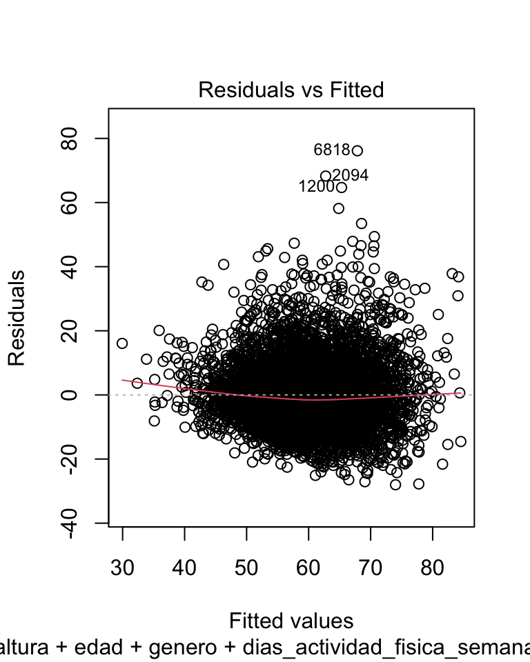

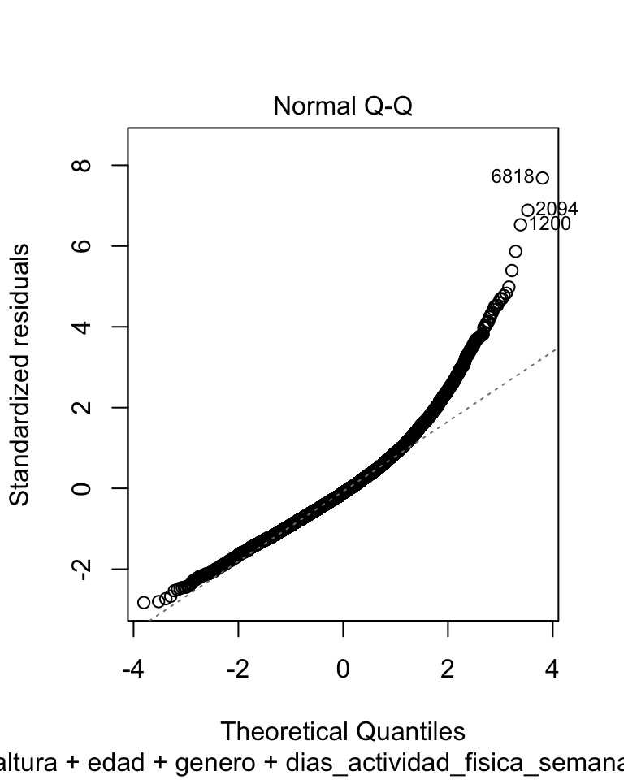

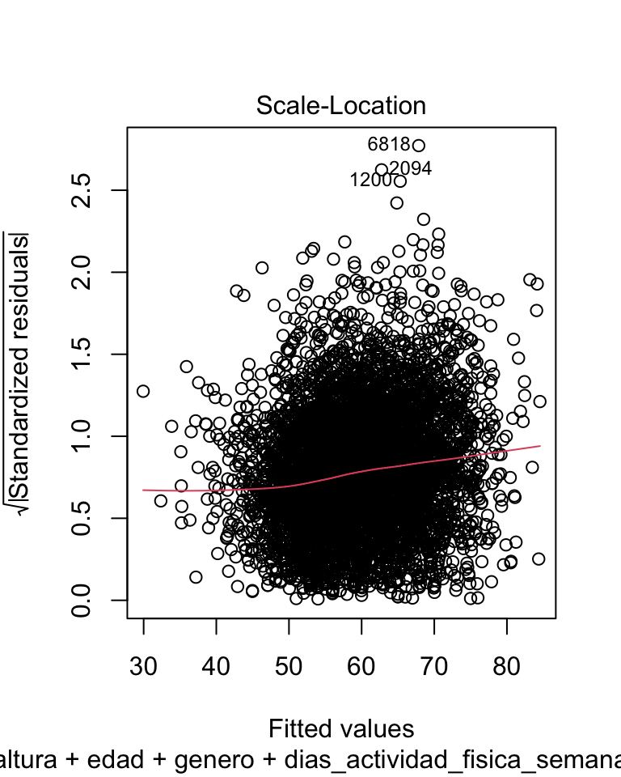

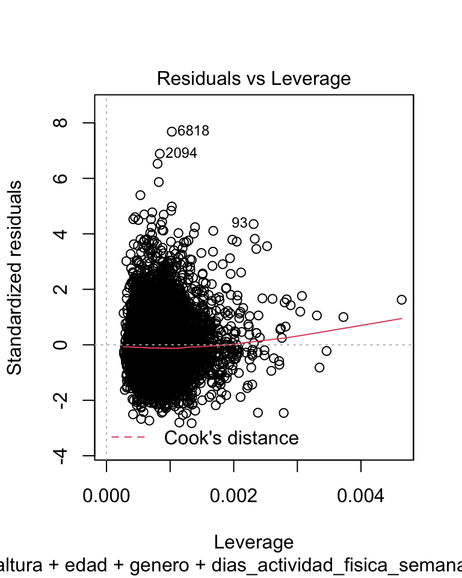

```r
plot(modelo_simple)
```

Residuos vs valores predichos: No parece existir una estructura clara entre los residuos y los valores predichos. Sucede algo similar en el gráfico scale-location.

Normal QQ plot: El extremo superior derecho no se ajusta a la distribución teórica, en este caso la ∼N(0,1), por lo que se deduce que **los residuos estandarizados no siguen esa distribución.**

Residual vs leverage: Existe un estudiante con un leverage por encima del resto, y que si bien no tiene un residuo considerablemente más grande, vamos a analizar el caso para entender si se trata de un posible outlier:

```r
lista_predicciones_training$modelo_simple %>%
  filter(.hat == max(.hat))
```

| peso | altura | edad | genero | dias_actividad_fisica_semanal | consumo_diario_alcohol | .fitted | .resid | .hat | .sigma | .cooksd | .std.resid |
| --- | --- | --- | --- | --- | --- | --- | --- | --- | --- | --- | --- |
| 46 | 125 | 12 | Masculino | 7 | 0 | 29.93476 | 16.06524 | 0.004639858 | 9.913216 | 0.002049448 | 1.624171 |

Se observa, entre otras cosas, que se trata de la persona más baja de toda la muestra: y si observamos un boxplot con las alturas de los niños de 12 años, está considerablemente abajo del promedio:

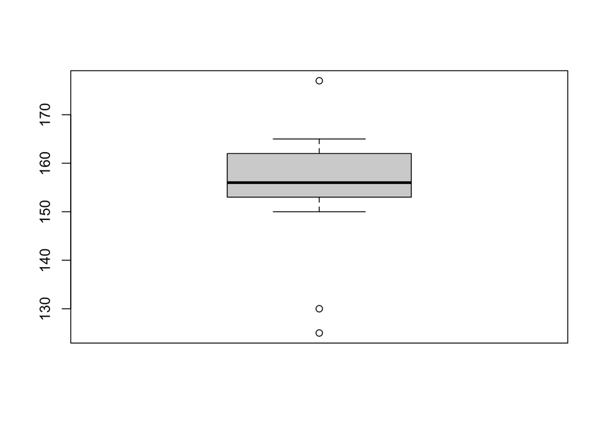

```r
boxplot(encuesta_salud %>% filter(edad == 12) %>% select(altura))
```

Quizás sea correcto excluir ese registro de la muestra y realizar nuevamente el ajuste, o aplicar alguna regresión robusta que haga un mejor tratamiento de ese tipo de observaciones.

#### **6) Modelo robusto**

Por último, se va a leer un nuevo dataset con algunos valores atípicos y vamos a volver a observar la relación entre peso y altura:

```r
encuesta_salud_outliers <- read.csv("encuesta_salud_modelo6.csv")
```

Observo cuáles son las variables afectadas por los outliers:

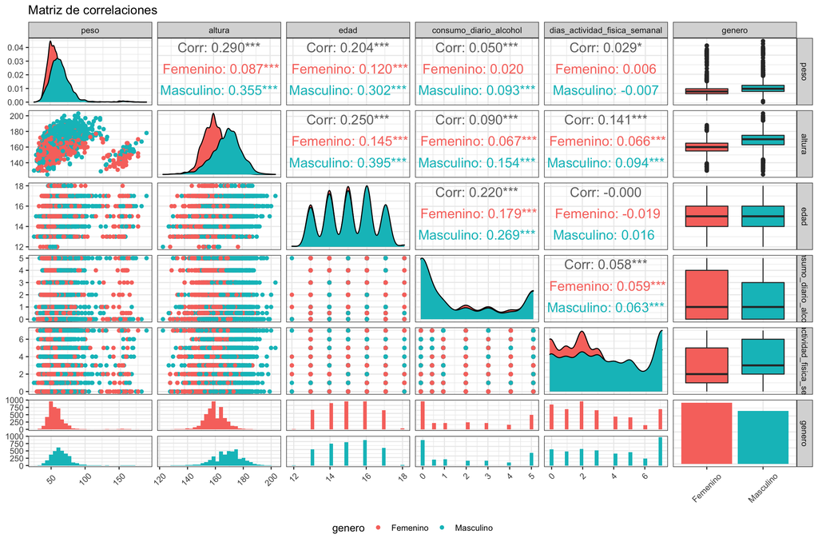

```r
encuesta_salud_outliers %>%
  select(peso,altura,edad,consumo_diario_alcohol,dias_actividad_fisica_semanal, genero) %>%
  ggpairs(mapping = aes(color = genero), title = "Matriz de correlaciones",
          upper = list(continuous = wrap("cor", size = 5, hjust=0.5)), legend = 25) +
  theme_bw() +
  theme(axis.text.x = element_text(angle=45, vjust=0.5), legend.position = "bottom")
```

En este caso, se va a utilizar una regresión robusta para lidiar con los valores atípicos: se ve menos afectada que la regresión tradicional cuando existen estos inconvenientes porque utiliza una versión de mínimos cuadrados ponderada por los residuos para sacarle el peso a los outliers.

Observamos el modelo ajustado:

```r
modelo_robusto <- lmRob(peso ~ altura + edad + genero + dias_actividad_fisica_semanal + consumo_diario_alcohol,data = encuesta_salud_outliers)

tidy_modelo_robusto <- tidy(modelo_robusto)
tidy_modelo_robusto
```

| term | estimate | std.error | statistic | p.value |
| --- | --- | --- | --- | --- |
| (Intercept) | -62.99100272 | 2.19963429 | -28.6370343 | 0.000000000000000000000000000000000000000000000000000000000000000000000000000000000000000000000000000000000000000000000000000000000000000000000000000000000000000000000000008253952 |
| altura | 0.61700925 | 0.01358874 | 45.4059277 | 0.000000000000000000000000000000000000000000000000000000000000000000000000000000000000000000000000000000000000000000000000000000000000000000000000000000000000000000000000000000000 |
| edad | 1.29209776 | 0.08726979 | 14.8057843 | 0.000000000000000000000000000000000000000000000000712484092389771366999080355958283328306950480452719902280724305518617239277989596589041020525389349533778355309590070952585616482 |
| generoMasculino | 1.09460224 | 0.25379663 | 4.3129109 | 0.000016329297140761115731321870270242868627974530681967735290527343750000000000000000000000000000000000000000000000000000000000000000000000000000000000000000000000000000000000000 |
| dias_actividad_fisica_semanal | -0.03408577 | 0.04641963 | -0.7342964 | 0.462792257693546149610597240098286420106887817382812500000000000000000000000000000000000000000000000000000000000000000000000000000000000000000000000000000000000000000000000000000 |
| consumo_diario_alcohol | 0.05268465 | 0.05712454 | 0.9222770 | 0.356415322241881216136505372560350224375724792480468750000000000000000000000000000000000000000000000000000000000000000000000000000000000000000000000000000000000000000000000000000 |

Los coeficientes que multiplican la altura y la edad no cambian sustancialmente si los comparamos con los que devolvió el primer modelo, y siguen siendo significativos para explicar el peso de una persona. Algo similar sucede con el coeficiente que acompaña al género. Días de actividad física semanal y consumo diario de alcohol siguen siendo no significativas para explicar el peso.

Ahora observamos el porcentaje de la varianza explicada por el modelo:

```r
glance(modelo_robusto)
```

| r.squared | deviance | sigma | df.residual | nobs |
| --- | --- | --- | --- | --- |
| 0.2887698 | 295483.1 | 8.583318 | 7123 | 7129 |

Se observa una baja considerable del $R^2$ de este nuevo modelo. Pasa de cerca del 0,35 a un 0,28. De todos modos, es una métrica que también se ve afectada por los outliers y quizás lo apropiado sea construir una versión robusta de la misma.

Para entender si el haber hecho una regresión robusta sirvió, vamos a observar qué tan bien performa el modelo en datos nuevos. Se va a utilizar nuevamente el RMSE y el MAE:

```r
peso = predict(modelo_robusto, newdata = encuesta_salud_test, se.fit = TRUE)

encuesta_salud_test$.fitted = peso$fit

rbind(rmse(data = encuesta_salud_test, truth = peso, estimate = .fitted),
mae(data = encuesta_salud_test, truth = peso, estimate = .fitted))
```

| .metric | .estimator | .estimate |
| --- | --- | --- |
| rmse | standard | 10.30525 |
| mae | standard | 7.49267 |

Si comparamos el RMSE y el MAE vs los modelos anteriormente analizados, se puede ver que por más que el modelo fue entrenado en un dataset con outliers la predicción no se deterioró mucho: el RMSE es apenas mayor que el del resto de los modelo y el MAE incluso da mejor que en el resto.